# Capstone Quiz I

Complete all **Exercises**, and submit answers to **Questions** on the Coursera platform.

This initial quiz will concern exploratory data analysis (EDA) of the Ames Housing dataset. EDA is essential when working with any source of data and helps inform modeling.

First, let us load the data:

```r
library(dplyr)
```

```r
library(tidyr)
library(ggplot2)
library(easyGgplot2)

library(GGally)
load("ames_train.Rdata")
```

1. Which of the following are the three variables with the highest number of missing observations?
   1. `Misc.Feature`, `Fence`, `Pool.QC`
   2. `Misc.Feature`, `Alley`, `Pool.QC`
   3. `Pool.QC`, `Alley`, `Fence`
   4. `Fireplace.Qu`, `Pool.QC`, `Lot.Frontage`

```r
# type your code for Question 1 here, and Knit
ames_train %>% summarise_each(funs(sum(is.na(.)))) %>% gather() %>% top_n(3)
```

```
## # A tibble: 3 × 2
##            key value
##          <chr> <int>
## 1        Alley   933
## 2      Pool.QC   997
## 3 Misc.Feature   971
```

2. How many categorical variables are coded in R as having type `int`? Change them to factors when conducting your analysis.
   1. 0
   2. 1
   3. 2
   4. 3

```r
# type your code for Question 2 here, and Knit
ames_train %>% select_if(function(col) !is.factor(col) ) %>% select_if(function(col) max(col,na.rm=T)<20) %>% str()
```

```
## Classes 'tbl_df', 'tbl' and 'data.frame':    1000 obs. of  12 variables:
##  $ Overall.Qual  : int  6 5 5 4 8 7 4 7 5 6 ...
##  $ Overall.Cond  : int  6 5 9 8 6 5 4 5 6 5 ...
##  $ Bsmt.Full.Bath: int  1 1 0 0 1 0 0 0 0 1 ...
##  $ Bsmt.Half.Bath: int  0 0 0 0 0 0 0 0 0 0 ...
##  $ Full.Bath     : int  1 2 1 1 2 3 1 2 1 1 ...
##  $ Half.Bath     : int  0 0 0 0 1 0 0 0 0 0 ...
##  $ Bedroom.AbvGr : int  2 2 2 2 3 4 2 2 3 2 ...
##  $ Kitchen.AbvGr : int  1 1 1 1 1 1 1 1 1 1 ...
##  $ TotRms.AbvGrd : int  4 5 5 6 6 7 4 5 6 5 ...
##  $ Fireplaces    : int  1 0 0 0 0 1 0 1 0 0 ...
##  $ Garage.Cars   : int  2 1 1 1 2 2 2 2 2 2 ...
##  $ Mo.Sold       : int  3 2 11 5 11 7 2 3 4 5 ...
```

```r
ames_train<-ames_train %>% mutate_each(funs(as.factor(.)),c(Overall.Qual,Overall.Cond))
```

3. In terms of price, which neighborhood has the highest standard deviation?
   1. `StoneBr`
   2. `Timber`
   3. `Veenker`
   4. `NridgHt`

```r
# type your code for Question 3 here, and Knit

group_neighborhood <- ames_train %>% group_by(Neighborhood) %>% summarise(sd=sd(price)) %>% top_n(n=1)
group_neighborhood
```

```
## # A tibble: 1 × 2
##   Neighborhood       sd
##         <fctr>    <dbl>
## 1      StoneBr 123459.1
```

4. Using scatter plots or other graphical displays, which of the following variables appears to be the best single predictor of `price`?
   1. `Lot.Area`
   2. `Bedroom.AbvGr`
   3. `Overall.Qual`
   4. `Year.Built`

```r
# type your code for Question 4 here, and Knit
max_cols<-ames_train %>% select(Lot.Area,Year.Built,Bedroom.AbvGr) %>%  summarise_each(funs(max,min))
dim(max_cols)
```

```
## [1] 1 6
```

```r
dim(ames_train)
```

```
## [1] 1000   81
```

```r
max_cols
```

```
## # A tibble: 1 × 6
##   Lot.Area_max Year.Built_max Bedroom.AbvGr_max Lot.Area_min
##          <int>          <int>             <int>        <int>
## 1       215245           2010                 6         1470
## # ... with 2 more variables: Year.Built_min <int>, Bedroom.AbvGr_min <int>
```

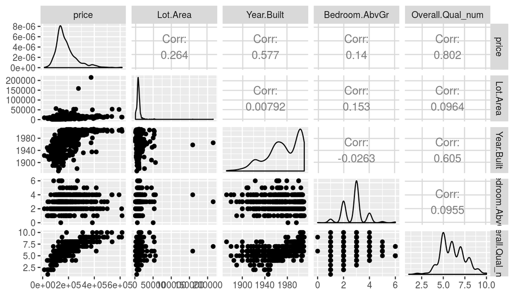

```r
ames_train$Overall.Qual_num<-as.numeric(ames_train$Overall.Qual)

ggpairs(ames_train,column=c("price","Lot.Area","Year.Built","Bedroom.AbvGr","Overall.Qual_num") )
```

5. Suppose you are examining the relationship between `price` and `area`. Which of the following variable transformations makes the relationship appear to be the most linear?
   1. Do not transform either `price` or `area`
   2. Log-transform `price` but not `area`
   3. Log-transform `area` but not `price`
   4. Log-transform both `price` and `area`

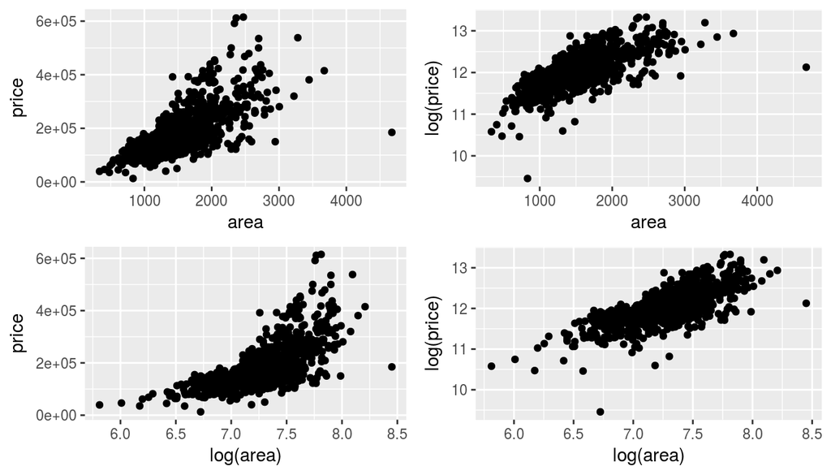

```r
# type your code for Question 5 here, and Knit

p0<-ggplot(ames_train,aes(area,price)) +geom_point()
p1<-ggplot(ames_train,aes(area,log(price))) +geom_point()
p2<-ggplot(ames_train,aes(log(area),price)) +geom_point()
p3<-ggplot(ames_train,aes(log(area),log(price))) +geom_point()

# Multiple graphs on the same page
ggplot2.multiplot(p0,p1,p2,p3, cols=2)
```

6. Suppose that your prior for the proportion of houses that have at least one garage is Beta(9, 1). What is your posterior? Assume a beta-binomial model for this proportion.
   1. Beta(954, 46)
   2. Beta(963, 46)
   3. Beta(954, 47)
   4. Beta(963, 47)

```r
# type your code for Question 6 here, and Knit
#the Beta posterior is : B(prior+successes,prior+failures)
table(ames_train$Garage.Type)
```

```
##
##  2Types  Attchd Basment BuiltIn CarPort  Detchd
##      10     610      11      56       1     266
```

```r
sum(table(ames_train$Garage.Type))
```

```
## [1] 954
```

```r
print('Beta(963,47)')
```

```
## [1] "Beta(963,47)"
```

7. Which of the following statements is true about the dataset?
   1. Over 30 percent of houses were built after the year 1999.
   2. The median housing price is greater than the mean housing price.
   3. 21 houses do not have a basement.
   4. 4 houses are located on gravel streets.

```r
# type your code for Question 7 here, and Knit

#Over 30 percent of houses were built after the year 1999.
print(sum(ames_train$Year.Built>1999)/nrow(ames_train)*100)
```

```
## [1] 27.2
```

```r
#The median housing price is greater than the mean housing price.

median(ames_train$price)
```

```
## [1] 159467
```

```r
mean(ames_train$price)
```

```
## [1] 181190.1
```

```r
#21 houses do not have a basement.
sum(table(ames_train$Bsmt.Qual))
```

```
## [1] 979
```

```r
#4 houses are located on gravel streets.
table(ames_train$Street)
```

```
##
## Grvl Pave
##    3  997
```

```r
print ('21 houses do not have a basement.')
```

```
## [1] "21 houses do not have a basement."
```

8. Test, at the $\alpha = 0.05$ level, whether homes with a garage have larger square footage than those without a garage.
   1. With a p-value near 0.000, we reject the null hypothesis of no difference.
   2. With a p-value of approximately 0.032, we reject the null hypothesis of no difference.
   3. With a p-value of approximately 0.135, we fail to reject the null hypothesis of no difference.
   4. With a p-value of approximately 0.343, we fail to reject the null hypothesis of no difference.

```r
# type your code for Question 8 here, and Knit
ames_train <- ames_train %>% mutate(no.Garage= is.na(Garage.Type) )
group_garage<- ames_train  %>% group_by(no.Garage) %>% summarise(n(),mean(area))
group_garage
```

```
## # A tibble: 2 × 3
##   no.Garage `n()` `mean(area)`
##       <lgl> <int>        <dbl>
## 1     FALSE   954     1492.603
## 2      TRUE    46     1145.043
```

```r
table(is.na(ames_train$Garage.Type))
```

```
##
## FALSE  TRUE
##   954    46
```

```r
noGarage<-ames_train %>% filter(no.Garage)
hasGarage<-ames_train %>% filter(!no.Garage)

meanNoGarage<-mean(noGarage$area)
meanHasGarage<-mean(hasGarage$area)

sdNoGarage<- sd(noGarage$area)
sdhasGarage<- sd(hasGarage$area)

sdNoGarage
```

```
## [1] 445.1805
```

```r
sdhasGarage
```

```
## [1] 502.5917
```

```r
# SE = sqrt[ (s1^2/n1) + (s2^2/n2) ]
SE<- sqrt( sdNoGarage^2/46 + sdhasGarage^2/954 )
SE
```

```
## [1] 67.62516
```

```r
DF <- 45

DF
```

```
## [1] 45
```

```r
2*pt((meanHasGarage-meanNoGarage)/SE,df = 50,lower.tail = F)
```

```
## [1] 4.583505e-06
```

9. For homes with square footage greater than 2000, assume that the number of bedrooms above ground follows a Poisson distribution with rate $\lambda$. Your prior on $\lambda$ follows a Gamma distribution with mean 3 and standard deviation 1. What is your posterior mean and standard deviation for the average number of bedrooms in houses with square footage greater than 2000 square feet?
   1. Mean: 3.61, SD: 0.11
   2. Mean: 3.62, SD: 0.16
   3. Mean: 3.63, SD: 0.09
   4. Mean: 3.63, SD: 0.91

```r
# type your code for Question 9 here, and Knit
ames_train_big<-ames_train %>% filter(area>2000)
sum(ames_train_big$Bedroom.AbvGr)
```

```
## [1] 501
```

```r
nrow(ames_train_big)
```

```
## [1] 138
```

```r
length(ames_train_big$Bedroom.AbvGr)
```

```
## [1] 138
```

```r
# prior :
mean<- 3
#mean = k*theta
sd<- 1
# sd = theta*sqrt(k)

k<-(mean/sd)^2
k
```

```
## [1] 9
```

```r
theta<-mean/k
theta
```

```
## [1] 0.3333333
```

```r
#average number of bedrooms in houses with square footage greater than 2000 square feet

# k*=k+number of room total
# tetha* = theta /(number of sample *theta +1)

# then :

k_<-k+sum(ames_train_big$Bedroom.AbvGr)
theta_<-theta/(length(ames_train_big$Bedroom.AbvGr)*theta+1)

k_
```

```
## [1] 510
```

```r
theta_
```

```
## [1] 0.007092199
```

```r
post_mean <- k_*theta_
post_sd <- theta_*sqrt(k_)

post_mean
```

```
## [1] 3.617021
```

```r
post_sd
```

```
## [1] 0.1601644
```

10. When regressing $\log$(`price`) on $\log$(`area`), there are some outliers. Which of the following do the three most outlying points have in common?
    1. They had abnormal sale conditions.
    2. They have only two bedrooms.
    3. They have an overall quality of less than 3.
    4. They were built before 1930.

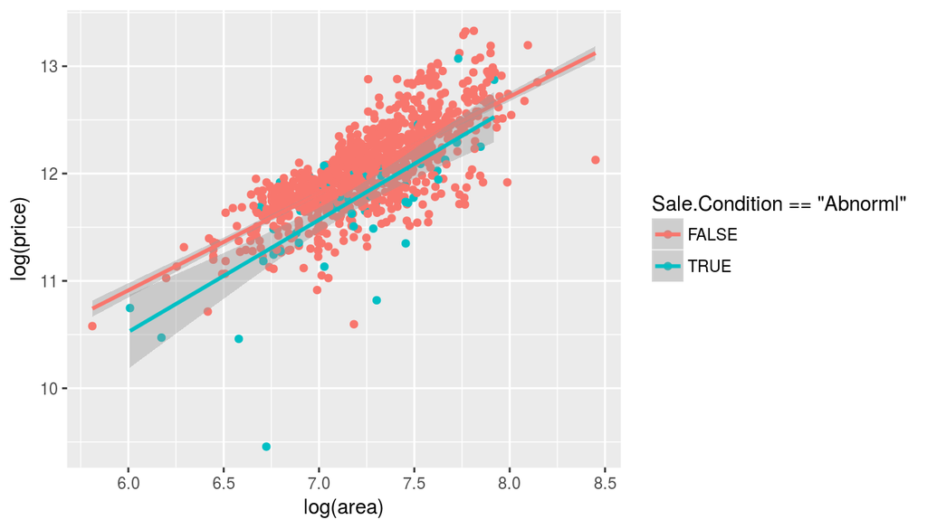

```r
# type your code for Question 10 here, and Knit

ggplot(ames_train,aes(x=log(area),y=log(price),colour=Sale.Condition=='Abnorml'))+ geom_point() +geom_smooth(method = 'lm')
```

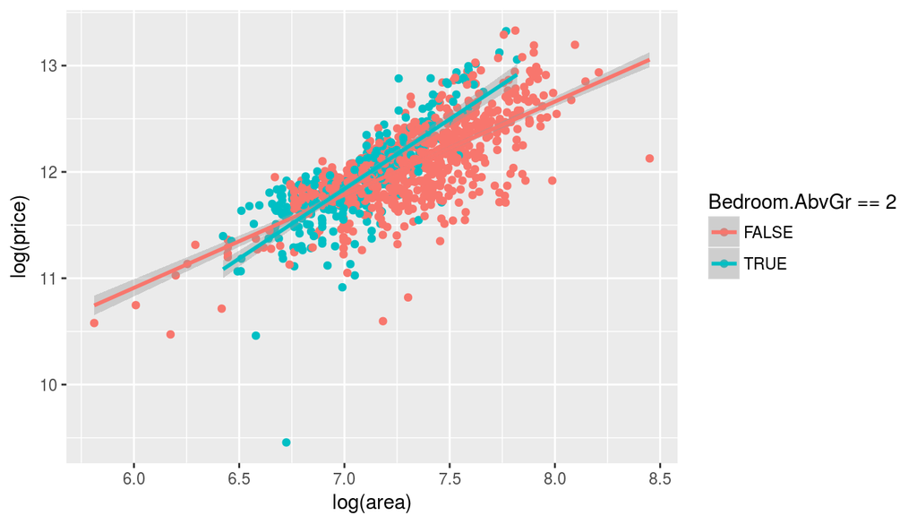

```r
ggplot(ames_train,aes(x=log(area),y=log(price),colour=Bedroom.AbvGr==2))+ geom_point()+geom_smooth(method = 'lm')
```

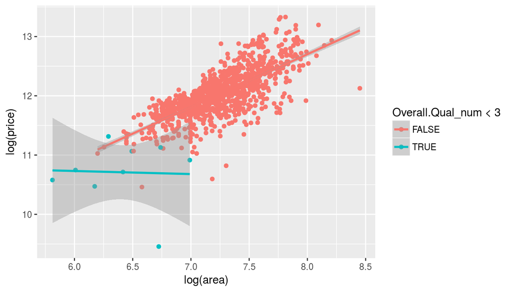

```r
ggplot(ames_train,aes(x=log(area),y=log(price),colour=Overall.Qual_num<3))+ geom_point()+geom_smooth(method = 'lm')
```

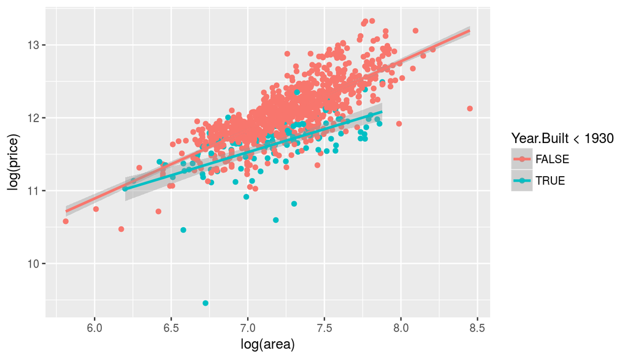

```r
ggplot(ames_train,aes(x=log(area),y=log(price),colour=Year.Built<1930))+ geom_point()+geom_smooth(method = 'lm')
```

11. Which of the following are reasons to log-transform `price` if used as a dependent variable in a linear regression?
    1. `price` is right-skewed.
    2. `price` cannot take on negative values.
    3. `price` can only take on integer values.
    4. Both a and b.

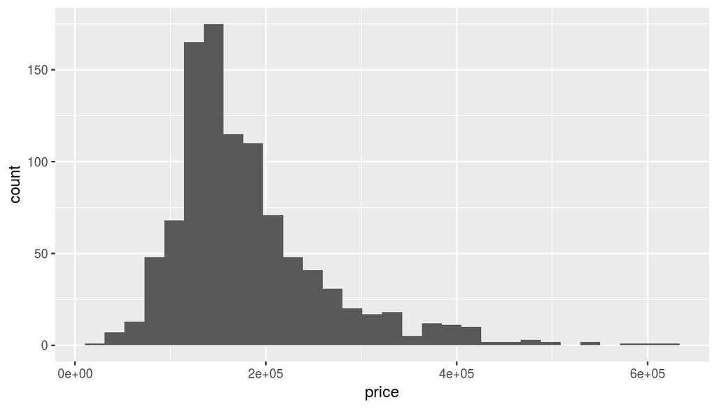

```r
# type your code for Question 11 here, and Knit


ggplot(ames_train,aes(x=price))+geom_histogram()
```

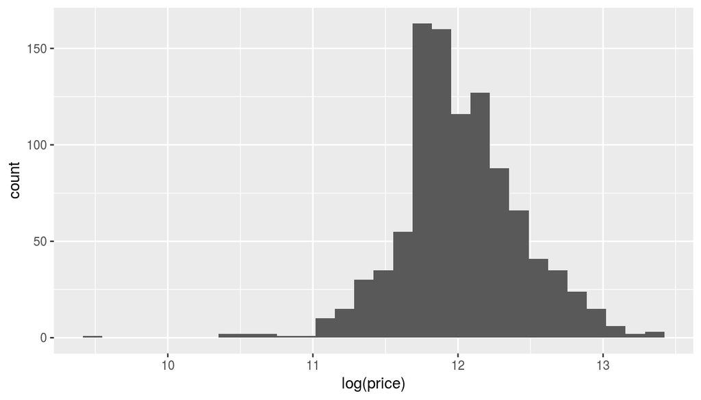

```r
ggplot(ames_train,aes(x=log(price)))+geom_histogram()
```

12. How many neighborhoods consist of only single-family homes? (e.g. `Bldg.Type` = `1Fam`)
    1. 0
    2. 1
    3. 2
    4. 3

```r
# type your code for Question 12 here, and Knit
ames_train %>% group_by(Neighborhood)  %>% summarise(total = n(), fam1 = sum(Bldg.Type=='1Fam')) %>% mutate(ratio=fam1/total) %>% filter(ratio==1)
```

```
## # A tibble: 3 × 4
##   Neighborhood total  fam1 ratio
##         <fctr> <int> <int> <dbl>
## 1      ClearCr    13    13     1
## 2      NoRidge    28    28     1
## 3       Timber    19    19     1
```

13. Using color, different plotting symbols, conditioning plots, etc., does there appear to be an association between $\log$(`area`) and the number of bedrooms above ground (`Bedroom.AbvGr`)?
    1. Yes
    2. No

```r
# type your code for Question 13 here, and Knit

cor(log(ames_train$area),ames_train$Bedroom.AbvGr)
```

```
## [1] 0.5457625
```

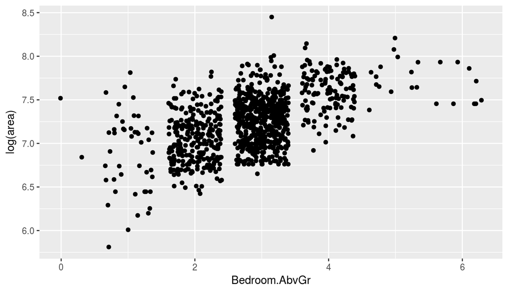

```r
ggplot(ames_train,aes(Bedroom.AbvGr,log(area))) + geom_jitter()
```

14. Of the people who have unfinished basements, what is the average square footage of the unfinished basement?
    1. 590.36
    2. 595.25
    3. 614.37
    4. 681.94

```r
# type your code for Question 14 here, and Knit

table(ames_train$BsmtFin.Type.1)
```

```
##
##     ALQ BLQ GLQ LwQ Rec Unf
##   1 163  87 294  48 107 279
```

```r
unf_bsmt<- ames_train %>% filter(!is.na(Bsmt.Unf.SF))
mean(unf_bsmt$Bsmt.Unf.SF)
```

```
## [1] 546.989
```